# Table of Contents

A6 Reinforcement Learning to Control a Robot

In this assignment, you will play with a simulation of a two-dimensional robot arm with multiple links and joints. You will train a neural network to approximate the Q function.

The state of the arm is just the angles of each joint. To remove the huge difference between joint angles of 359 degrees and 1 degree as a joint moves, we will represent each joint angle with two values, the sine and cosine of the angle, as the state input to the neural network. Valid actions on each step will be $-0.1$, $0$, and $+0.1$ applied to each joint.

# `Robot` class

Here is an implementation of the robot simulation.

```python
import numpy as np
import copy
import matplotlib.pyplot as plt
import sys
import itertools  # for product (cross product)
from math import pi
from IPython.display import display, clear_output
```

Now import your `NeuralNetwork` regression class that uses `numpy` and has the `scg` optimizer available.

```python
import neuralnetworksA4 as nn  # where you implement the NeuralNetwork class
```

```python
class Robot():

    def __init__(self, link_lengths):
        self.n_links = len(link_lengths)
        self.record_angles = False
        self.angles = []
        self.link_lengths = np.array(link_lengths)
        self.joint_angles = np.zeros(self.n_links)
        self.points = [[10, 10] for _ in range(self.n_links + 1)]
        self.lim = sum(link_lengths)
        self.update_points()
        self.goal = None

    def set_goal(self, g):
        self.goal = g

    def dist_to_goal(self):
        return np.sqrt(np.sum((self.goal - self.end_effector)**2))

    def update_joints(self, joint_angles):
        self.joint_angles = joint_angles
        self.update_points()

    def add_to_joints(self, joint_angle_deltas):
        self.joint_angles += joint_angle_deltas
        too_high = self.joint_angles > 2 * pi
        self.joint_angles[too_high] = self.joint_angles[too_high] - 2 * pi
        too_low = self.joint_angles < 0
        self.joint_angles[too_low] = self.joint_angles[too_low] + 2 * pi
        if self.record_angles:
            self.angles.append(self.joint_angles * 180 / pi)
        self.update_points()

    def update_points(self):
        for i in range(1, self.n_links + 1):
            self.points[i][0] = (self.points[i - 1][0]
                                 + self.link_lengths[i - 1] * np.cos(np.sum(self.joint_angles[:i])))
            self.points[i][1] = (self.points[i - 1][1] +
                                 self.link_lengths[i - 1] * np.sin(np.sum(self.joint_angles[:i])))
        self.end_effector = np.array(self.points[self.n_links]).T

    def get_angles(self):
        return self.joint_angles


    def plot(self, style):
        for i in range(self.n_links + 1):
            if i is not self.n_links:
                plt.plot([self.points[i][0], self.points[i + 1][0]],
                         [self.points[i][1], self.points[i + 1][1]], style)
            plt.plot(self.points[i][0], self.points[i][1], 'k.')
        plt.axis('off')
        plt.axis('square')
        plt.xlim([-1, 21])
        plt.ylim([-1, 21])

    def animate(self, n_steps, Qnet=None, show_all_steps=False):
        fig = plt.figure(figsize=(8, 8))

        for i in range(n_steps):
            if not show_all_steps:
                fig.clf()
            plt.scatter(self.goal[0], self.goal[1], s=80)
            if Qnet:
                action, Qvalue = epsilon_greedy(self, Qnet, valid_actions, epsilon=0)
            else:
                action = [0.1] * self.n_links
            self.add_to_joints(action)
            style = 'b-' if show_all_steps and i+1 == n_steps else 'r-'
            self.plot(style)

            if not show_all_steps:
                clear_output(wait=True)
                display(fig)

        if not show_all_steps:
            clear_output(wait=True)
```

To use this class, first instantiate a robot by specifying the number of links and the lengths of each link as a list. Imagine the end of the last link of the robot has a gripper. Set the goal location for the gripper by calling `robot.set_goal()`.

Then you can animate the robot for some number of steps.

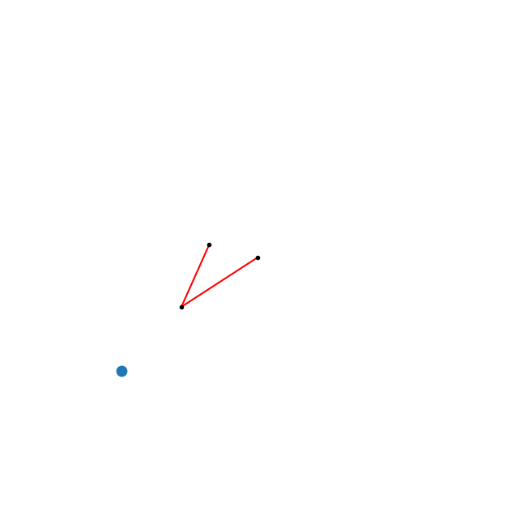

```python
robot = Robot([4, 3])
robot.set_goal([4, 5])
robot.animate(100)
```

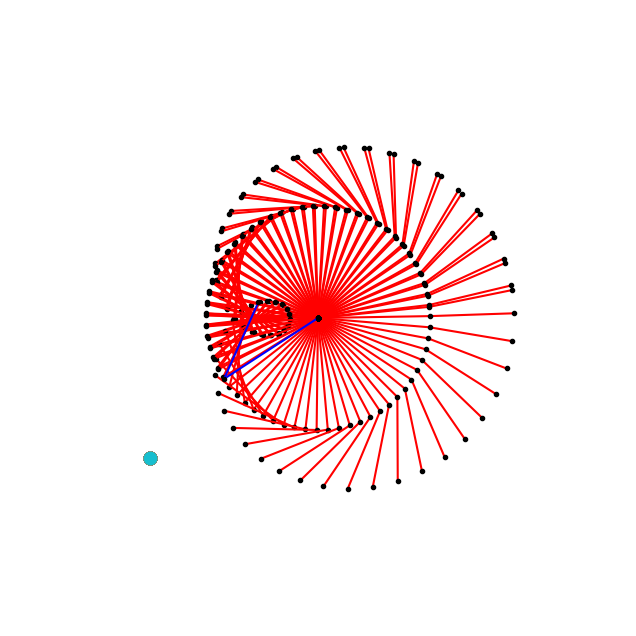

```python
robot = Robot([4, 3])
robot.set_goal([4, 5])
robot.animate(100, show_all_steps=True)
```

# Reinforcement Learning Problem for Controlling the Robot

To define the reinforcement learning problem for controlling this robot, and trying to move the gripper as close to the goal as you can, we need to define the three main functions that define a reinforcement learning problem. These are pretty easy with the functions available to us in the `Robot` class. We will also need a function to represent the joint angles as sines and cosines.

```python
def angles_to_sin_cos(angles):
    return np.hstack((np.sin(angles), np.cos(angles)))


def initial_state(robot):
    robot.update_joints(np.random.uniform(-2 * pi, 2 * pi, size=(robot.n_links)))
    angles = robot.get_angles()
    state = angles_to_sin_cos(angles)
    return state


def next_state(robot, action):
    robot.add_to_joints(action)
    angles = robot.get_angles()
    state = angles_to_sin_cos(angles)
    return state


def reinforcement(robot):
    '''Objective is to move gripper to the goal location as quickly as possible.'''
    dist_to_goal = robot.dist_to_goal()
    return dist_to_goal
```

```python
angles_to_sin_cos([0, pi/4, pi/2, pi, -pi])
```

```
array([ 0.00000000e+00,  7.07106781e-01,  1.00000000e+00,  1.22464680e-16,
       -1.22464680e-16,  1.00000000e+00,  7.07106781e-01,  6.12323400e-17,
       -1.00000000e+00, -1.00000000e+00])
```

```python
initial_state(robot)
```

```
array([-0.91678477, -0.95997351,  0.39938163, -0.28009079])
```

```python
next_state(robot, [-1, 1])
```

```
array([-0.83140898, -0.75436418, -0.55566097,  0.65645616])
```

```python
reinforcement(robot)
```

```
1.5225629931234002
```

Now we need our two workhorse functions, `epsilon_greedy` and `make_samples`.

```python
def epsilon_greedy(robot, Qnet, valid_actions, epsilon):
    state = angles_to_sin_cos(robot.get_angles())

    if np.random.uniform() < epsilon:

        # Random Move
        actioni = np.random.randint(valid_actions.shape[0])
        action = valid_actions[actioni]

    else:
        # Greedy Move

        Qs = [Qnet.use(np.hstack((state, a)).reshape((1, -1))) for a in valid_actions]
        ai = np.argmin(Qs)
        action = valid_actions[ai]

    Q = Qnet.use(np.hstack((state, action)).reshape((1, -1)))

    return action, Q
```

```python
def make_samples(robot, Qnet, initial_state_f, next_state_f, reinforcement_f,
                 valid_actions, n_samples, epsilon):

    X = np.zeros((n_samples, Qnet.n_inputs))
    R = np.zeros((n_samples, 1))
    Qn = np.zeros((n_samples, 1))

    state = initial_state_f(robot)
    state = next_state_f(robot, [0] * robot.n_links)  # 0 action for all joints
    action, _ = epsilon_greedy(robot, Qnet, valid_actions, epsilon)

    # Collect data from numSamples steps
    for step in range(n_samples):

        next_state = next_state_f(robot, action)
        r = reinforcement_f(robot)
        next_action, next_Q = epsilon_greedy(robot, Qnet, valid_actions, epsilon)

        X[step, :] = np.hstack((state, action))
        R[step, 0] = r
        Qn[step, 0] = next_Q

        # Advance one time step
        state, action = next_state, next_action

    return (X, R, Qn)
```

# Reinforcement Learning Training Algorithm

```python
def setup_standardization(Qnet, Xmeans, Xstds, Tmeans, Tstds):
    Qnet.X_means = np.array(Xmeans)
    Qnet.X_stds = np.array(Xstds)
    Qnet.T_means = np.array(Tmeans)
    Qnet.T_stds = np.array(Tstds)

def train(robot, n_hiddens_list, valid_actions, n_trials, n_steps_per_trial, n_scg_iterations,
          final_epsilon, gamma=0.8, verbose=False):

    epsilon_decay = np.exp(np.log(final_epsilon) / (n_trials))  # to produce this final value

    n_inputs = robot.n_links * 2 + robot.n_links

    Qnet = nn.NeuralNetwork(n_inputs, n_hiddens_list, 1)

    means_state = [0] * robot.n_links * 2
    means_actions = [0] * robot.n_links
    stds_states = [0.5] * robot.n_links * 2
    stds_actions = [1.0] * robot.n_links
    setup_standardization(Qnet, means_state + means_actions, stds_states + stds_actions, [0], [1])

    epsilon = 1         # initial epsilon value
    epsilon_trace = []
    r_mean_trace = []
    r_trace = np.zeros((n_trials * n_steps_per_trial, 1))

    for trial in range(n_trials):

        # Collect n_steps_per_trial samples

        X, R, Qn = make_samples(robot, Qnet, initial_state, next_state, reinforcement,
                                valid_actions, n_steps_per_trial, epsilon)

        # Train Qnet on these samples for n_scg_iterations
        Qnet.train(X, R + gamma * Qn, n_scg_iterations, method='scg', verbose=verbose)

        # Update the three traces
        epsilon_trace.append(epsilon)
        i = trial * n_steps_per_trial
        j = i + n_steps_per_trial
        r_trace[i:j, :] = R
        r_mean_trace.append(np.mean(R))

        # Decay epsilon
        epsilon *=  epsilon_decay
        epsilon = max(final_epsilon, epsilon)

#         if trial + 1 == n_trials or (trial + 1) % (n_trials // 10) == 0:
#             print(f'Trial {trial+1}: Mean R {r_mean_trace[-1]:.2f}')

    return Qnet, r_mean_trace, r_trace, epsilon_trace
```

```python
single_joint_actions = [-0.1, 0, 0.1]
valid_actions =  np.array(list(itertools.product(single_joint_actions, repeat=robot.n_links)))
```

```python
robot = Robot([3., 3.])
robot.set_goal([5., 6.])
```

```python
robot
```

```
<__main__.Robot at 0x2a0e8629cd0>
```

```python
n_hiddens_list = [50, 10]
n_trials = 200
n_steps_per_trial = 1000
n_scg_iterations = 4
final_epsilon = 0.01
gamma = 0.9

np.random.seed(42)
Qnet, r_mean_trace, r_trace, epsilon_trace = train(robot, n_hiddens_list, valid_actions, n_trials,
                                                   n_steps_per_trial, n_scg_iterations,
                                                   final_epsilon, gamma, verbose=True)
```

```
SCG: Iteration 1 RMSE=1.77271
SCG: Iteration 2 RMSE=1.16746
SCG: Iteration 3 RMSE=0.89749
SCG: Iteration 4 RMSE=0.73457
SCG: Iteration 1 RMSE=5.55931
SCG: Iteration 2 RMSE=3.38611
SCG: Iteration 3 RMSE=3.38611
SCG: Iteration 4 RMSE=3.38611
SCG: Iteration 1 RMSE=3.49748
SCG: Iteration 2 RMSE=3.29551
SCG: Iteration 3 RMSE=3.00838
SCG: Iteration 4 RMSE=2.90533
SCG: Iteration 1 RMSE=4.95823
SCG: Iteration 2 RMSE=3.47379
SCG: Iteration 3 RMSE=2.68837
SCG: Iteration 4 RMSE=2.12545
SCG: Iteration 1 RMSE=3.52604
SCG: Iteration 2 RMSE=3.00421
SCG: Iteration 3 RMSE=2.96553
SCG: Iteration 4 RMSE=2.60330
SCG: Iteration 1 RMSE=5.04979
SCG: Iteration 2 RMSE=5.04979
SCG: Iteration 3 RMSE=5.04979
SCG: Iteration 4 RMSE=4.51841
SCG: Iteration 1 RMSE=4.52306
SCG: Iteration 2 RMSE=4.00097
SCG: Iteration 3 RMSE=3.67944
SCG: Iteration 4 RMSE=3.12447
SCG: Iteration 1 RMSE=4.44923
SCG: Iteration 2 RMSE=3.39457
SCG: Iteration 3 RMSE=3.09781
SCG: Iteration 4 RMSE=3.01320
SCG: Iteration 1 RMSE=4.38891
SCG: Iteration 2 RMSE=3.94902
SCG: Iteration 3 RMSE=2.37578
SCG: Iteration 4 RMSE=2.17053
SCG: Iteration 1 RMSE=3.85074
SCG: Iteration 2 RMSE=3.26030
SCG: Iteration 3 RMSE=3.24435
SCG: Iteration 4 RMSE=2.76301
```

[output cut: 745 more lines]

```
SCG: Iteration 2 RMSE=0.57013
SCG: Iteration 3 RMSE=0.55140
SCG: Iteration 4 RMSE=0.53499
SCG: Iteration 1 RMSE=0.40555
SCG: Iteration 2 RMSE=0.39917
SCG: Iteration 3 RMSE=0.39656
SCG: Iteration 4 RMSE=0.39197
SCG: Iteration 1 RMSE=0.41827
SCG: Iteration 2 RMSE=0.41021
SCG: Iteration 3 RMSE=0.40783
SCG: Iteration 4 RMSE=0.40364
SCG: Iteration 1 RMSE=0.65325
SCG: Iteration 2 RMSE=0.64653
SCG: Iteration 3 RMSE=0.64209
SCG: Iteration 4 RMSE=0.63906
```

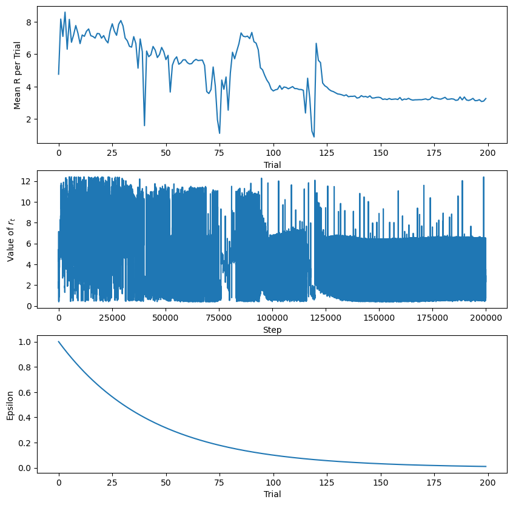

```python
import matplotlib.pyplot as plt

plt.figure(figsize=(10, 10))
plt.clf()
plt.subplot(3, 1, 1)
plt.plot(r_mean_trace)
plt.xlabel('Trial')
plt.ylabel('Mean R per Trial')

plt.subplot(3, 1, 2)
plt.plot(r_trace)
plt.xlabel('Step')
plt.ylabel('Value of $r_t$')

plt.subplot(3, 1, 3)
plt.plot(epsilon_trace)
plt.xlabel('Trial')
plt.ylabel('Epsilon');
```

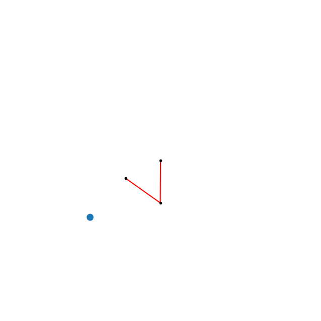

```python
import numpy as np
np.random.seed(1234)
initial_state(robot)
robot.animate(100, Qnet)
```

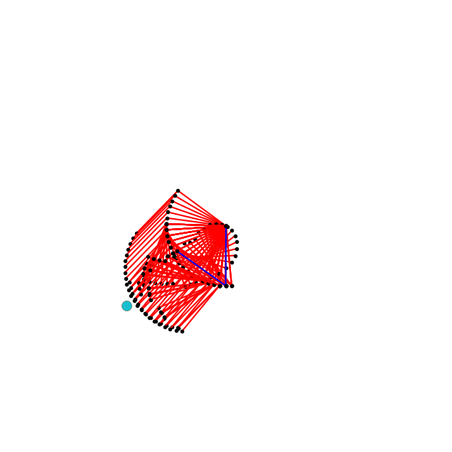

```python
np.random.seed(1234)
initial_state(robot)
robot.animate(100, Qnet, show_all_steps=True)
```

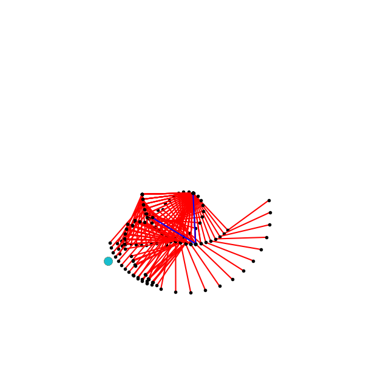

```python
np.random.seed(4444)
initial_state(robot)
robot.animate(100, Qnet, show_all_steps=True)
```

# Required Experiments

Show the results and discuss what you see. Which parameter values result in the best performance during and at the end of training?

## Good parameter values

Find values for parameters `n_hiddens_list`, `n_trials`, `n_steps_per_trial`, `n_scg_iterations`, and `gamma` that result in Mean R per Trial plot that shows fairly steady decrease to value close to 0.

```python
import itertools


def make_param_grid(list_trials, steps_per_trial, n_scg_iters, final_epsilon, gamma, hidden_lists):
    """
    Makes a gridspace with all possible combinations of input parameters.

    """
    param_combs = list(itertools.product(*[list_trials, steps_per_trial, n_scg_iters, final_epsilon, gamma,
                                           hidden_lists]))
    return param_combs
```

### Parameter Initialization

I am creating parameter grids of following values to run the test.  
- n_trials = [200, 400]  
- n_steps_per_trial = [500, 1000]  
- n_scg_iterations = [4, 6]  
- final_epsilon = [0.01, 0.5]  
- gamma = [0.9, 0.2]  
- n_hiddens_list = [[50, 10], [30]]

As there are a lot of parameters to investigate and it takes signifiant time to run the model without `cuda` support, I will be mostly focusing on some parameters `final_epsilon`, `gamma`, and `hidden_layers`. `final_epsilon` and `gamma` are two significant parameters in reinforcement learning, hence I am trying both of this parameters for high and low values.

Low `final_epsilon` signifies `greedy moves` by the model, meaning the model will try out best moves more rather than random moves. `gamma` represents how much the model considers future actions. High `gamma` represents more future actions.

In total, I will run 64 models with differnet combinations of parameters.

```python
# List of parameters

list_n_trials = [200, 400]
list_n_steps_per_trial = [500, 1000]
list_n_scg_iterations = [4, 6]
list_final_epsilon = [0.01, 0.5]
list_gamma = [0.9, 0.2]
list_n_hiddens_list = [[50, 10], [30]]

params = make_param_grid(list_n_trials, list_n_steps_per_trial, list_n_scg_iterations, list_final_epsilon, list_gamma,
                         list_n_hiddens_list)
len(params)
```

```
64
```

```python
final_r_mean_trace = []
model_idx = []

i = 0
for param in params:
    n_trials, n_steps_per_trial, n_scg_iterations, final_epsilon, gamma, n_hiddens_list = param
    print(f'running model {i}...')

    np.random.seed(42)
    Qnet, r_mean_trace, r_trace, epsilon_trace = train(robot, n_hiddens_list, valid_actions, n_trials,
                                                   n_steps_per_trial, n_scg_iterations,
                                                   final_epsilon, gamma, verbose=False)
    last_50_r_mean = r_mean_trace[-50:]

    final_r_mean_trace.append(r_mean_trace)
    model_idx.append(i)

    if np.mean(last_50_r_mean) < 2:
        print('idx for model with r_mean closing to zero: ', i)
        print('parameters:', param)

    i+=1
```

```
running model 0...
running model 1...
idx for model with r_mean closing to zero:  1
parameters: (200, 500, 4, 0.01, 0.9, [30])
running model 2...
running model 3...
idx for model with r_mean closing to zero:  3
parameters: (200, 500, 4, 0.01, 0.2, [30])
running model 4...
running model 5...
idx for model with r_mean closing to zero:  5
parameters: (200, 500, 4, 0.5, 0.9, [30])
running model 6...
idx for model with r_mean closing to zero:  6
parameters: (200, 500, 4, 0.5, 0.2, [50, 10])
running model 7...
idx for model with r_mean closing to zero:  7
parameters: (200, 500, 4, 0.5, 0.2, [30])
running model 8...
idx for model with r_mean closing to zero:  8
parameters: (200, 500, 6, 0.01, 0.9, [50, 10])
running model 9...
idx for model with r_mean closing to zero:  9
parameters: (200, 500, 6, 0.01, 0.9, [30])
running model 10...
idx for model with r_mean closing to zero:  10
parameters: (200, 500, 6, 0.01, 0.2, [50, 10])
running model 11...
idx for model with r_mean closing to zero:  11
parameters: (200, 500, 6, 0.01, 0.2, [30])
running model 12...
idx for model with r_mean closing to zero:  12
parameters: (200, 500, 6, 0.5, 0.9, [50, 10])
running model 13...
idx for model with r_mean closing to zero:  13
parameters: (200, 500, 6, 0.5, 0.9, [30])
running model 14...
idx for model with r_mean closing to zero:  14
parameters: (200, 500, 6, 0.5, 0.2, [50, 10])
running model 15...
```

[output cut: 127 more lines]

```
running model 59...
idx for model with r_mean closing to zero:  59
parameters: (400, 1000, 6, 0.01, 0.2, [30])
running model 60...
idx for model with r_mean closing to zero:  60
parameters: (400, 1000, 6, 0.5, 0.9, [50, 10])
running model 61...
idx for model with r_mean closing to zero:  61
parameters: (400, 1000, 6, 0.5, 0.9, [30])
running model 62...
idx for model with r_mean closing to zero:  62
parameters: (400, 1000, 6, 0.5, 0.2, [50, 10])
running model 63...
idx for model with r_mean closing to zero:  63
parameters: (400, 1000, 6, 0.5, 0.2, [30])
```

```python
def checkforless(a_list, val):
    return (all(x < val for x in a_list))

selected_idx_trace = []

for idx, trace in enumerate(final_r_mean_trace):
    t = trace[-30:]
    if checkforless(t, 1.2):
        selected_idx_trace.append(idx)

print(f'models with index {selected_idx_trace} have r_mean values closing to zero')
```

```
models with index [9, 25, 32, 33, 40, 41, 49, 51, 52, 57, 58, 60] have r_mean values closing to zero
```

From the model runs, models with index [9, 25, 32, 33, 40, 41, 49, 51, 52, 57, 58, 60] are doing well.

```python
filtered_params = []

for j in selected_idx_trace:
    print(f'models with r_mean values closing to zero has params')
    print(params[j])
    filtered_params.append(params[j])
```

```
models with r_mean values closing to zero has params
(200, 500, 6, 0.01, 0.9, [30])
models with r_mean values closing to zero has params
(200, 1000, 6, 0.01, 0.9, [30])
models with r_mean values closing to zero has params
(400, 500, 4, 0.01, 0.9, [50, 10])
models with r_mean values closing to zero has params
(400, 500, 4, 0.01, 0.9, [30])
models with r_mean values closing to zero has params
(400, 500, 6, 0.01, 0.9, [50, 10])
models with r_mean values closing to zero has params
(400, 500, 6, 0.01, 0.9, [30])
models with r_mean values closing to zero has params
(400, 1000, 4, 0.01, 0.9, [30])
models with r_mean values closing to zero has params
(400, 1000, 4, 0.01, 0.2, [30])
models with r_mean values closing to zero has params
(400, 1000, 4, 0.5, 0.9, [50, 10])
models with r_mean values closing to zero has params
(400, 1000, 6, 0.01, 0.9, [30])
models with r_mean values closing to zero has params
(400, 1000, 6, 0.01, 0.2, [50, 10])
models with r_mean values closing to zero has params
(400, 1000, 6, 0.5, 0.9, [50, 10])
```

```python
print(len(filtered_params))
filtered_params
```

```
12
```

```
[(200, 500, 6, 0.01, 0.9, [30]),
 (200, 1000, 6, 0.01, 0.9, [30]),
 (400, 500, 4, 0.01, 0.9, [50, 10]),
 (400, 500, 4, 0.01, 0.9, [30]),
 (400, 500, 6, 0.01, 0.9, [50, 10]),
 (400, 500, 6, 0.01, 0.9, [30]),
 (400, 1000, 4, 0.01, 0.9, [30]),
 (400, 1000, 4, 0.01, 0.2, [30]),
 (400, 1000, 4, 0.5, 0.9, [50, 10]),
 (400, 1000, 6, 0.01, 0.9, [30]),
 (400, 1000, 6, 0.01, 0.2, [50, 10]),
 (400, 1000, 6, 0.5, 0.9, [50, 10])]
```

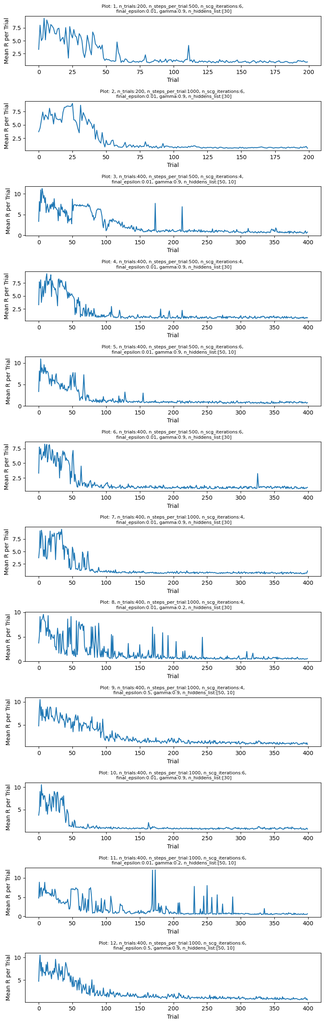

```python
plt.subplots(12, 1, figsize = (8, 25))

plot_i = 1
for i in selected_idx_trace:
    plt.subplot(12, 1, plot_i)
    plt.plot(final_r_mean_trace[i])
    plt.xlabel('Trial')
    plt.ylabel('Mean R per Trial')
    plt.title('Plot: {}, n_trials:{}, n_steps_per_trial:{}, n_scg_iterations:{}, \n final_epsilon:{}, gamma:{}, n_hiddens_list:{}'.format(plot_i, params[i][0], params[i][1], params[i][2], params[i][3], params[i][4], params[i][5]), fontsize=8)
    plot_i+=1

plt.tight_layout()
```

### Model Selection robot 2-link

Out of 64 model run, I filtered `12 models` with the criteria that their `last 30 mean_R values are less than 1.2`. The value 1.2 is an arbritary number that I chose for filtering.

For this particular problem, models with simplier hidden layer structure are doing better. `7 out of 12` models have simpler hidden layer structure.

Based on the `mean R` plots, I am choosing the following model (plot 10) as the best model (altough other models have similar performance)for their decreasing and consistent trend towards zero.  
`- Plot 10: n_trials=400, n_steps_per_trial=1000, n_scg_iterations=6, final_epsilon=0.01, gamma=0.9, n_hiddens_list=[30]`

## Create robot with four links of lengths, 4, 3, 3, and 2.

Again, find good values for the parameters.

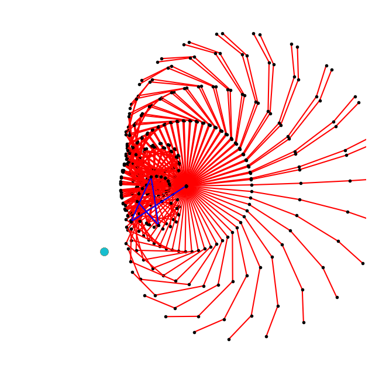

```python
robot_4link = Robot([4., 3., 3., 2.])
robot_4link.set_goal([5., 6.])
robot_4link.animate(100, show_all_steps=True)
```

```python
single_joint_actions = [-0.1, 0, 0.1]
valid_actions =  np.array(list(itertools.product(single_joint_actions, repeat=robot_4link.n_links)))
```

**Based on the previous model run, I am selecting `6 models` for running the 4 link robot.** The parameters are showed in the following cell.

```python
filtered_params_4links = [filtered_params[i] for i in [1, 3, 4, 6, 9, 11]]
filtered_params_4links
```

```
[(200, 1000, 6, 0.01, 0.9, [30]),
 (400, 500, 4, 0.01, 0.9, [30]),
 (400, 500, 6, 0.01, 0.9, [50, 10]),
 (400, 1000, 4, 0.01, 0.9, [30]),
 (400, 1000, 6, 0.01, 0.9, [30]),
 (400, 1000, 6, 0.5, 0.9, [50, 10])]
```

```python
for param in filtered_params_4links:
    n_trials, n_steps_per_trial, n_scg_iterations, final_epsilon, gamma, n_hiddens_list = param
    print(f'running model...')

    np.random.seed(42)
    Qnet2, r_mean_trace_4link, r_trace_4link, epsilon_trace_4link = train(robot_4link, n_hiddens_list, valid_actions,
                                                                          n_trials, n_steps_per_trial, n_scg_iterations,
                                                                          final_epsilon, gamma, verbose=False)
    final_r_mean_trace_4link.append(r_mean_trace_4link)
```

```
running model...
running model...
running model...
running model...
running model...
running model...
```

[figure not shown]

```python
plt.subplots(6, 1, figsize = (8, 15))

plot_i = 1
for i in range(len(final_r_mean_trace_4link)):
    plt.subplot(6, 1, plot_i)
    plt.plot(final_r_mean_trace_4link[i])
    plt.xlabel('Trial')
    plt.ylabel('Mean R per Trial')
    plt.ylim([0, 15])
    plt.title('Plot: {}, n_trials:{}, n_steps_per_trial:{}, n_scg_iterations:{}, \n final_epsilon:{}, gamma:{}, n_hiddens_list:{}'.format(plot_i, params[i][0], params[i][1], params[i][2], params[i][3], params[i][4], params[i][5]), fontsize=8)
    plot_i+=1

plt.tight_layout()
```